# PAC 1 Dades omiques

Balma Albalat Oliver

#INFORME ##1.DESCRIPCIÓ I JUSTIFICACIO DE LA BASE DE DADES ## He triat la database associada al projecte Metabolomics of Psoriasis. ## Aquesta pot consular-se en el repositori “Metabolomics workbench” amb l’identificador de projecte PR000239. ## He triat aquest tema perquè pateixo aquesta malaltia i m’ha causat curiositat #aprofundir en aquesta qüestió. ## Es tracta d’un estudi desenvolupat pel Departament de Dermatologia de la Universitat de Michigan, dirigit per l’investigador Johann Gudjonsson. L’objectiu de l’estudi és estudiar els metabolits esteroides en els teixits de pacients amb diferents estats de psoriasis. Per assolir-lo es van realitzar biòpsis per obtenir 9 mostres de pell que es van categoritzar en 3 subgrups:

#-Pell sana (3) -Pell afectada per psoriasis (3) -Pell no afectada en pacients amb psoriasis (3)

#A través de la cromatografía líquida acoplada a l’espectrometria de masses (LC-MS) es van analitzar les concentracions d’esteroides, expressades en pg/mg de teixit, caracteritzant d’aquesta manera els perfils metabòlics de cada mostra de pell.

```r
if (!require(plotly)) {
    install.packages("plotly")
    library(plotly)
}
if (!require(ggridges)) {
    install.packages("ggridges")
    library(ggridges)
}
if (!require(ggrepel)) {
    install.packages("ggrepel")
    library(ggrepel)
}
if (!require(ggforce)) {
    install.packages("ggforce")
    library(ggforce)
}
if (!require(kableExtra)) {
    install.packages("kableExtra")
    library(kableExtra)
}
if (!require(patchwork)) {
    install.packages("patchwork")
    library(ggridges)
}
if (!require(tidyr)) {
    install.packages("tidyr")
    library(tidyr)
}
if (!require(flextable)) {
    install.packages("flextable")
    library(flextable)
}
if (!require(officer)) {
    install.packages("officer")
    library(officer)
}
if (!require(pheatmap)) {
    install.packages("pheatmap")
    library(pheatmap)
}
paquets <- c("ggplot2", "ggridges", "dplyr", "tidyr", "patchwork")
paquets_no_instalats <- paquets[!paquets %in% installed.packages()[, "Package"]]
if(length(paquets_no_instalats)) install.packages(paquets_no_instalats)
suppressPackageStartupMessages(lapply(paquets, require, character.only = TRUE))
```

```
## [[1]]
## [1] TRUE
##
## [[2]]
## [1] TRUE
##
## [[3]]
## [1] TRUE
##
## [[4]]
## [1] TRUE
##
## [[5]]
## [1] TRUE
```

```r
if(!require(jsonlite)){
    install.packages("jsonlite")
    library(jsonlite)}
if (!require("BiocManager", quietly = TRUE))
    install.packages("BiocManager")
if (!require("ggtext", quietly = TRUE))
    install.packages("ggtext")
if (!require("magrittr", quietly = TRUE))
    install.packages("magrittr")
if (!require("dplyr", quietly = TRUE))
    install.packages("dplyr")
if (!require("tidyr", quietly = TRUE))
    install.packages("tidyr")
if (!require("tibble", quietly = TRUE))
    install.packages("tibble")
if (!require("purrr", quietly = TRUE))
    install.packages("purrr")
if (!require("readr", quietly = TRUE))
    install.packages("readr")
if (!require("reshape2", quietly = TRUE))
    install.packages("reshape2")
```

```r
if (!require("pheatmap", quietly = TRUE))
    install.packages("pheatmap")
if (!require("RColorBrewer", quietly = TRUE))
    install.packages("RColorBrewer")
library(reshape2)
library(pheatmap)
library(RColorBrewer)
if (!requireNamespace("SummarizedExperiment", quietly = TRUE)) {
  install.packages("SummarizedExperiment")
}
if (!requireNamespace("ggplot2", quietly = TRUE)) {
  install.packages("ggplot2")
}

BiocManager::install("Biobase")
BiocManager::install("POMA")
BiocManager::install("SummarizedExperiment")
library(POMA)
library(ggtext)
library(magrittr)
library(SummarizedExperiment)
library(readr)
library(purrr)
library(ggplot2)
```

```r
##### PREPARACIÓ I IMPORTACIÓ DE LES DADES ####

# Importar l'arxiu de dades '.json'

library(jsonlite)
json_data <-jsonlite::fromJSON("ST000298_AN000476.json", flatten = TRUE)
# Cerquem i resolem valors nuls #
null_values <- sapply(json_data, function(x) any(is.null(x)))
na_values <- sapply(json_data, function(x) any(is.na(x)))
# Print results
print("Valors nuls en:")
```

```
## [1] "Valors nuls en:"
```

```r
print(names(json_data)[null_values])
```

```
## character(0)
```

```r
### Creació colData (info i factor mostres) ###
# Extraem la info de json_data
if (is.data.frame(json_data$SUBJECT_SAMPLE_FACTORS)) {
  sample_df <- json_data$SUBJECT_SAMPLE_FACTORS
} else {
  sample_info <- as.character(unlist(data$SUBJECT_SAMPLE_FACTORS))
  sample_df <- read.table(text = sample_info, sep = "\t", header = FALSE, stringsAsFactors = FALSE)
}
colnames(sample_df) <- c("Subject", "SampleID", "Factors")

# Associem els factors a columnes i creem colData#

# Crear un DataFrame de factores
factor_df <- data.frame(Factor = sample_df$Factors)

# Combinar con el DataFrame original
colData <- cbind(sample_df[, "SampleID", drop = FALSE], factor_df)

# Asignar nombres a las filas
row.names(colData) <- colData$SampleID

# Ver el resultado
head(colData)
```

```
##            SampleID               Factor
## S00017314 S00017314   Psoriasis involved
## S00017315 S00017315   Psoriasis involved
## S00017316 S00017316   Psoriasis involved
## S00017317 S00017317 Psoriasis uninvolved
## S00017318 S00017318 Psoriasis uninvolved
## S00017319 S00017319 Psoriasis uninvolved
```

```r
### Extreuracció de dades metabòliques (fe) ###
# L'utilitzarem per a fer els anàlisi #

metabolite_data<-json_data$MS_METABOLITE_DATA$Data
metabolite_matrix <- as.data.frame(metabolite_data)
rownames(metabolite_matrix) <- metabolite_matrix$Metabolite
metabolite_matrix <- t(metabolite_matrix)
metabolite_matrix <- as.matrix(sapply(metabolite_matrix, as.numeric))
head(metabolite_matrix)
```

```
##                  [,1]
## 11-deoxycortisol   NA
## 0.570            0.57
## 0.610            0.61
## 0                0.00
## 0.31             0.31
## 2.68             2.68
```

```r
metabolite_data <- json_data$MS_METABOLITE_DATA$Data
metabolite_matrix <- as.data.frame(metabolite_data)
rownames(metabolite_matrix) <- metabolite_matrix$Metabolite
metabolite_matrix <- metabolite_matrix[, -1]  # Eliminar la columna redundant
metabolite_matrix[metabolite_matrix == ""] <- NA
metabolite_matrix <- as.matrix(sapply(metabolite_matrix, as.numeric))
head(metabolite_matrix)
```

```
##      S00017317 S00017315 S00017322 S00017316 S00017318 S00017319 S00017320
## [1,]      0.57      0.61      0.00      0.31      2.68      0.26      0.93
## [2,]      1.76      0.48      3.74      0.97      3.05      1.29      5.26
## [3,]      0.18      6.83     29.85    111.35    109.30     53.91    337.19
## [4,]      0.60      4.62      4.86      3.82      7.71      8.01     17.09
## [5,]      0.57        NA      0.85        NA        NA      0.82        NA
## [6,]      6.10      3.30     23.00     24.10     20.10     21.70    130.80
##      S00017321 S00017314
## [1,]      3.33      1.43
## [2,]      9.88      2.05
## [3,]   2126.34     66.98
## [4,]    105.27      4.02
## [5,]        NA      0.63
## [6,]    915.40     26.60
```

```r
#APROFITEM PER REVISAR VALORS FALTANTS O NULS
is.na(metabolite_matrix)
```

```
##       S00017317 S00017315 S00017322 S00017316 S00017318 S00017319 S00017320
##  [1,]     FALSE     FALSE     FALSE     FALSE     FALSE     FALSE     FALSE
##  [2,]     FALSE     FALSE     FALSE     FALSE     FALSE     FALSE     FALSE
##  [3,]     FALSE     FALSE     FALSE     FALSE     FALSE     FALSE     FALSE
##  [4,]     FALSE     FALSE     FALSE     FALSE     FALSE     FALSE     FALSE
##  [5,]     FALSE      TRUE     FALSE      TRUE      TRUE     FALSE      TRUE
##  [6,]     FALSE     FALSE     FALSE     FALSE     FALSE     FALSE     FALSE
##  [7,]     FALSE     FALSE     FALSE     FALSE     FALSE     FALSE     FALSE
##  [8,]     FALSE     FALSE     FALSE     FALSE     FALSE     FALSE     FALSE
##  [9,]     FALSE     FALSE     FALSE     FALSE     FALSE     FALSE     FALSE
##       S00017321 S00017314
##  [1,]     FALSE     FALSE
##  [2,]     FALSE     FALSE
##  [3,]     FALSE     FALSE
##  [4,]     FALSE     FALSE
##  [5,]      TRUE     FALSE
##  [6,]     FALSE     FALSE
##  [7,]     FALSE     FALSE
##  [8,]     FALSE     FALSE
##  [9,]     FALSE     FALSE
```

```r
row_na_counts <- rowSums(is.na(metabolite_matrix))
# Mostrar metabolits amb NA
row_na_counts[row_na_counts > 0]
```

```
## [1] 5
```

2. CREAR OBJECTE ‘SummarizedExperiment’

```r
# Comprovem que coincideixen les files

nrow(metabolite_matrix)
```

```
## [1] 9
```

```r
nrow(colData)
```

```
## [1] 9
```

```r
# Generm el SummarizedExperiment

library(POMA)
poma_obj <- PomaCreateObject(
  metadata = colData,
  features = metabolite_matrix
)

# Verifiquem

poma_obj
```

```
## class: SummarizedExperiment
## dim: 9 9
## metadata(0):
## assays(1): ''
## rownames(9): S00017317 S00017315 ... S00017321 S00017314
## rowData names(0):
## colnames(9): S00017314 S00017315 ... S00017321 S00017322
## colData names(1): Factor
```

3. AFEGIM METADADES GENERALS DEL PROJECTE (METADATA)

```r
# Afegim les metadades a l'objecte SummarizedExperiment
for (key in names(json_data$METABOLOMICS)) {
  metadata(poma_obj)$METABOLOMICS[[key]] <- json_data$METABOLOMICS[[key]]
}
for (key in names(json_data$PROJECT)) {
  metadata(poma_obj)$PROJECT[[key]] <- json_data$PROJECT[[key]]
}

for (key in names(json_data$STUDY)) {
  metadata(poma_obj)$STUDY[[key]] <- json_data$STUDY[[key]]
}

for (key in names(json_data$SUBJECT)) {
  metadata(poma_obj)$SUBJECT[[key]] <- json_data$SUBJECT[[key]]
}

for (key in names(json_data$SUBJECT_SAMPLE_FACTORS)) {
  metadata(poma_obj)$SUBJECT_SAMPLE_FACTORS[[key]] <- json_data$SUBJECT_SAMPLE_FACTORS[[key]]
}

for (key in names(json_data$COLLECTION)) {
  metadata(poma_obj)$COLLECTION[[key]] <- json_data$COLLECTION[[key]]
}

for (key in names(json_data$TREATMENT)) {
  metadata(poma_obj)$TREATMENT[[key]] <- json_data$TREATMENT[[key]]
}

for (key in names(json_data$SAMPLEPREP)) {
  metadata(poma_obj)$SAMPLEPREP[[key]] <- json_data$SAMPLEPREP[[key]]
}

for (key in names(json_data$CHROMATOGRAPHY)) {
  metadata(poma_obj)$CHROMATOGRAPHY[[key]] <- json_data$CHROMATOGRAPHY[[key]]
}

for (key in names(json_data$ANALYSIS)) {
  metadata(poma_obj)$ANALYSIS[[key]] <- json_data$ANALYSIS[[key]]
}

for (key in names(json_data$MS)) {
  metadata(poma_obj)$MS[[key]] <- json_data$MS[[key]]
}
for (key in names(json_data$MS_METABOLITE_DATA)) {
  metadata(poma_obj)$MS_METABOLITE_DATA[[key]] <- json_data$MS_METABOLITE_DATA[[key]]
}
metadata(poma_obj)
```

```
## $METABOLOMICS
## $METABOLOMICS$STUDY_ID
## [1] "ST000298"
##
## $METABOLOMICS$ANALYSIS_ID
## [1] "AN000476"
##
## $METABOLOMICS$VERSION
## [1] "1"
##
## $METABOLOMICS$CREATED_ON
## [1] "December 28, 2015, 11:42 am"
##
##
## $PROJECT
## $PROJECT$PROJECT_TITLE
## [1] "Metabolomics of Psoriasis"
##
## $PROJECT$PROJECT_SUMMARY
## [1] "Metabolomics of Psoriasis"
##
## $PROJECT$INSTITUTE
## [1] "University of Michigan"
##
## $PROJECT$DEPARTMENT
## [1] "Dermatology"
##
## $PROJECT$LABORATORY
## [1] "Gudjonsson Lab"
##
## $PROJECT$LAST_NAME
## [1] "Gudjonsson"
##
## $PROJECT$FIRST_NAME
## [1] "Johann"
##
## $PROJECT$ADDRESS
## [1] "Ann Arbor, MI"
##
## $PROJECT$EMAIL
```

[output cut: 152 more lines]

```
## 7       8.4       5.1      16.6       6.2
## 8      8.36     82.13    136.38     11.35
## 9      0.29      2.59      2.41      0.46
##
## $MS_METABOLITE_DATA$Metabolites
##               Metabolite PubChem CID
## 1       11-deoxycortisol      440707
## 2                 11-DOC        6166
## 3 17-Hydroxyprogesterone        6238
## 4        Androstenedione        6128
## 5         Corticosterone        5753
## 6               Cortisol        5754
## 7              Cortisone      222786
## 8           Progesterone        5994
## 9           Testosterone        6013
```

```r
save(poma_obj, file = "summarized_experiment.rda")
```

4. REVISEM LA INFO DE L’OBJECTE

```r
sample_df <- json_data$SUBJECT_SAMPLE_FACTORS
colnames(sample_df) <- c("Subject", "SampleID", "Factors")

colData <- data.frame(
  Factor = sample_df$Factors,
  row.names = sample_df$SampleID
)

metabolite_data <- json_data$MS_METABOLITE_DATA$Data
rownames(metabolite_data) <- metabolite_data$Metabolite
metabolite_data <- metabolite_data[, -1]

assay_matrix <- as.matrix(metabolite_data)
mode(assay_matrix) <- "numeric"
assay_matrix <- assay_matrix[, rownames(colData), drop = FALSE]

poma_obj <- SummarizedExperiment(
  assays = list(counts = assay_matrix),
  colData = colData
)
is.na(assay(poma_obj))
```

```
##                        S00017314 S00017315 S00017316 S00017317 S00017318
## 11-deoxycortisol           FALSE     FALSE     FALSE     FALSE     FALSE
## 11-DOC                     FALSE     FALSE     FALSE     FALSE     FALSE
## 17-Hydroxyprogesterone     FALSE     FALSE     FALSE     FALSE     FALSE
## Androstenedione            FALSE     FALSE     FALSE     FALSE     FALSE
## Corticosterone             FALSE      TRUE      TRUE     FALSE      TRUE
## Cortisol                   FALSE     FALSE     FALSE     FALSE     FALSE
## Cortisone                  FALSE     FALSE     FALSE     FALSE     FALSE
## Progesterone               FALSE     FALSE     FALSE     FALSE     FALSE
## Testosterone               FALSE     FALSE     FALSE     FALSE     FALSE
##                        S00017319 S00017320 S00017321 S00017322
## 11-deoxycortisol           FALSE     FALSE     FALSE     FALSE
## 11-DOC                     FALSE     FALSE     FALSE     FALSE
## 17-Hydroxyprogesterone     FALSE     FALSE     FALSE     FALSE
## Androstenedione            FALSE     FALSE     FALSE     FALSE
## Corticosterone             FALSE      TRUE      TRUE     FALSE
## Cortisol                   FALSE     FALSE     FALSE     FALSE
## Cortisone                  FALSE     FALSE     FALSE     FALSE
## Progesterone               FALSE     FALSE     FALSE     FALSE
## Testosterone               FALSE     FALSE     FALSE     FALSE
```

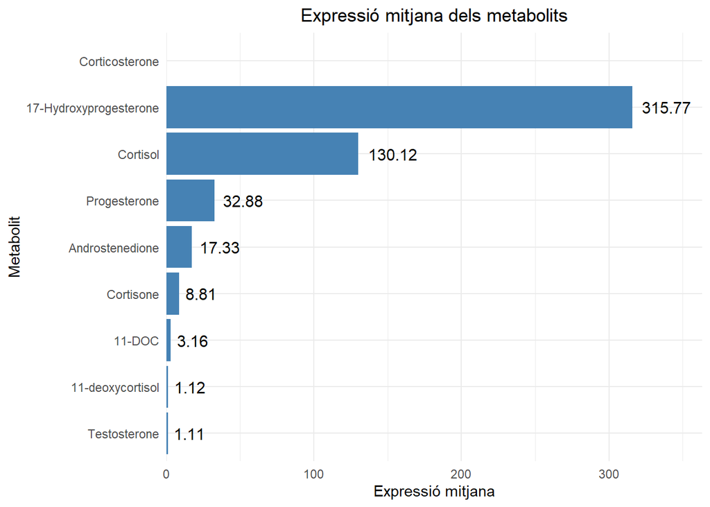

```r
#GRÀFIC DADES METABÒLITS

expr_matrix <- assay(poma_obj)
metabolite_means <- rowMeans(expr_matrix) #Calculem els valors mitjans
#Gràfic amb ggplot2
df_plot <- data.frame(
  Metabolite = rownames(expr_matrix),
  MeanExpression = metabolite_means
)
ggplot(df_plot, aes(x = reorder(Metabolite, MeanExpression), y = MeanExpression)) +
  geom_bar(stat = "identity", fill = "steelblue") +
  geom_text(aes(label = round(MeanExpression, 2)),
            hjust = -0.2,  # Desplaçar les etiquetes a la dreta
            size = 4) +
  coord_flip() +  # Rotar el gràfic per millor visualització
  scale_y_continuous(expand = expansion(mult = c(0, 0.15))) +  # Espai addicional a la dreta
  labs(title = "Expressió mitjana dels metabolits",
       x = "Metabolit",
       y = "Expressió mitjana") +
  theme_minimal() +
  theme(plot.title = element_text(hjust = 0.5))  # Centrar el títol
```

```r
##ALERTA, DADES NA en CORTICOSTERONE
```

DADES DESCRIPTIVES I NORMALITZACIÓ

```r
library(flextable)
library(officer)
library(SummarizedExperiment)
library(ggplot2)
library(reshape2)

# SUMMARY
summary(assay(poma_obj))
```

```
##    S00017314       S00017315        S00017316         S00017317
##  Min.   : 0.46   Min.   :0.3000   Min.   :  0.310   Min.   :0.180
##  1st Qu.: 1.43   1st Qu.:0.5775   1st Qu.:  0.905   1st Qu.:0.570
##  Median : 4.02   Median :2.4200   Median :  5.485   Median :0.600
##  Mean   :13.30   Mean   :2.6225   Mean   : 19.926   Mean   :2.928
##  3rd Qu.:11.35   3rd Qu.:3.6300   3rd Qu.: 14.275   3rd Qu.:6.100
##  Max.   :66.98   Max.   :6.8300   Max.   :111.350   Max.   :8.900
##                  NA's   :1        NA's   :1
##    S00017318         S00017319       S00017320         S00017321
##  Min.   :  1.590   Min.   : 0.26   Min.   :  0.930   Min.   :   2.410
##  1st Qu.:  2.958   1st Qu.: 0.82   1st Qu.:  4.473   1st Qu.:   8.242
##  Median : 11.005   Median : 8.01   Median : 11.175   Median :  60.935
##  Mean   : 23.852   Mean   :11.45   Mean   : 72.636   Mean   : 414.451
##  3rd Qu.: 23.098   3rd Qu.: 8.40   3rd Qu.: 94.297   3rd Qu.: 331.135
##  Max.   :109.300   Max.   :53.91   Max.   :337.190   Max.   :2126.340
##  NA's   :1                         NA's   :1         NA's   :1
##    S00017322
##  Min.   : 0.000
##  1st Qu.: 1.100
##  Median : 4.860
##  Mean   : 8.743
##  3rd Qu.: 9.290
##  Max.   :29.850
##
```

```r
summary_table <- summary(assay(poma_obj))

# Taula a df
summary_df <- as.data.frame(summary_table)
# Guardem la taula
table_flex <- flextable(summary_df) %>%
  theme_vanilla() %>%          # Estil
  autofit()                    # Ajusta
doc <- read_docx() %>%
  body_add_flextable(table_flex) %>%
  body_add_par("Resum de les dades per mostra", style = "heading 1")

print(doc, target = "Resum_POMA.docx")
```

5. PRE-PROCESSAT DE LES DADES Sí, cal normalitzar les dades. Treballarem amb log(poma_obj).

```r
library(ggplot2)
# MISSING VALUES #

is.na(assay(poma_obj))
```

```
##                        S00017314 S00017315 S00017316 S00017317 S00017318
## 11-deoxycortisol           FALSE     FALSE     FALSE     FALSE     FALSE
## 11-DOC                     FALSE     FALSE     FALSE     FALSE     FALSE
## 17-Hydroxyprogesterone     FALSE     FALSE     FALSE     FALSE     FALSE
## Androstenedione            FALSE     FALSE     FALSE     FALSE     FALSE
## Corticosterone             FALSE      TRUE      TRUE     FALSE      TRUE
## Cortisol                   FALSE     FALSE     FALSE     FALSE     FALSE
## Cortisone                  FALSE     FALSE     FALSE     FALSE     FALSE
## Progesterone               FALSE     FALSE     FALSE     FALSE     FALSE
## Testosterone               FALSE     FALSE     FALSE     FALSE     FALSE
##                        S00017319 S00017320 S00017321 S00017322
## 11-deoxycortisol           FALSE     FALSE     FALSE     FALSE
## 11-DOC                     FALSE     FALSE     FALSE     FALSE
## 17-Hydroxyprogesterone     FALSE     FALSE     FALSE     FALSE
## Androstenedione            FALSE     FALSE     FALSE     FALSE
## Corticosterone             FALSE      TRUE      TRUE     FALSE
## Cortisol                   FALSE     FALSE     FALSE     FALSE
## Cortisone                  FALSE     FALSE     FALSE     FALSE
## Progesterone               FALSE     FALSE     FALSE     FALSE
## Testosterone               FALSE     FALSE     FALSE     FALSE
```

```r
#Eliminem valors NA
poma_obj <- PomaImpute(poma_obj, method = "knn", zeros_as_na = TRUE, remove_na = TRUE, cutoff = 20)
```

```
## 1 features removed.
```

```r
sum(is.na(assay(poma_obj)))
```

```
## [1] 0
```

```r
row_na_counts <- rowSums(is.na(assay(poma_obj)))

# Mostrar metabolitos con valores faltantes
row_na_counts[row_na_counts > 0]
```

```
## named numeric(0)
```

```r
# CAL NORMALITZAR LES DADES? #

normalized <- poma_obj %>% PomaNorm(method = "log_pareto")
colData(normalized) <- colData(poma_obj)
normalized
```

```
## class: SummarizedExperiment
## dim: 8 9
## metadata(0):
## assays(1): ''
## rownames(8): X11.deoxycortisol X11.DOC ... Progesterone Testosterone
## rowData names(0):
## colnames(9): S00017314 S00017315 ... S00017321 S00017322
## colData names(1): Factor
```

```r
# OUTLIERS ? #

# Extraer el factor de grupo (tratamientos) desde la estructura interna
colData(normalized)
```

```
## DataFrame with 9 rows and 1 column
##                         Factor
##                    <character>
## S00017314   Psoriasis involved
## S00017315   Psoriasis involved
## S00017316   Psoriasis involved
## S00017317 Psoriasis uninvolved
## S00017318 Psoriasis uninvolved
## S00017319 Psoriasis uninvolved
## S00017320               Normal
## S00017321               Normal
## S00017322               Normal
```

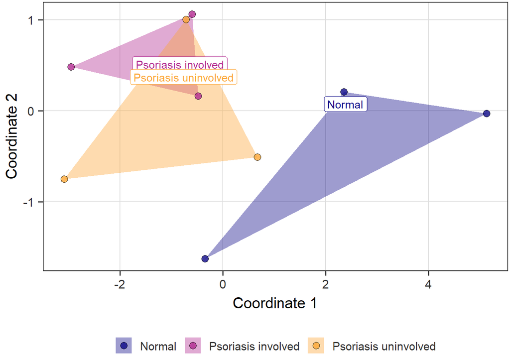

```r
group_factor <- normalized@colData@listData$Factor
group_factor <- factor(group_factor)
# Plot poligonal
p10<-PomaOutliers(normalized)$polygon_plot
p10
```

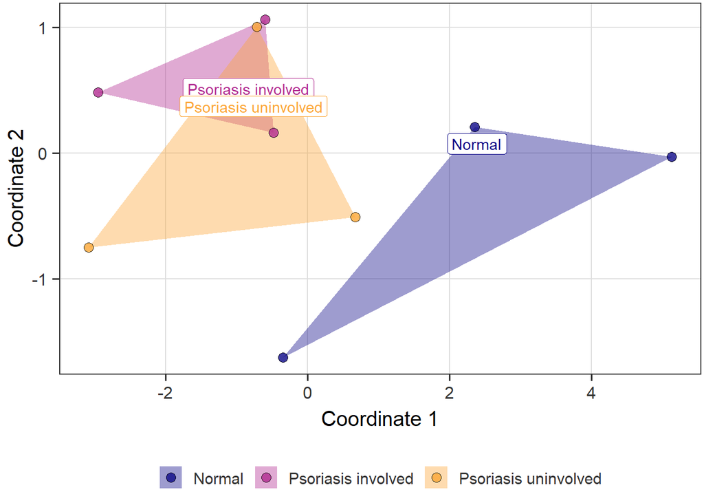

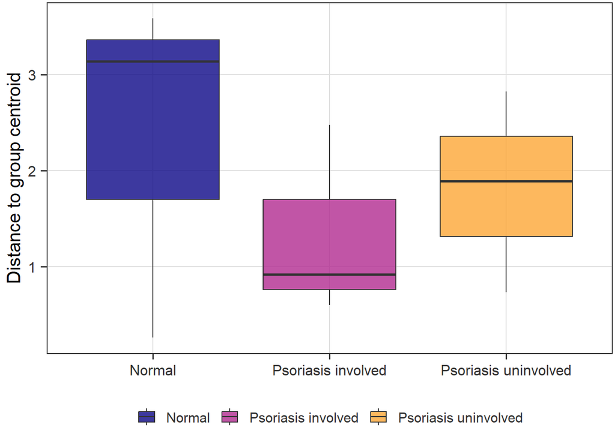

```
##
## $outliers
## # A tibble: 0 × 4
## # ℹ 4 variables: sample <chr>, groups <fct>, distance_to_centroid <dbl>,
## #   limit_distance <dbl>
##
## $data
## class: SummarizedExperiment
## dim: 8 9
## metadata(0):
## assays(1): ''
## rownames(8): X11.deoxycortisol X11.DOC ... Progesterone Testosterone
## rowData names(0):
## colnames(9): S00017314 S00017315 ... S00017321 S00017322
## colData names(1): Factor
```

```r
# Boxplot
outlier_results2 <- normalized %>%
  PomaOutliers(method = "euclidean",
               type = "median",
               outcome = "Factor",
               coef = 2,
               labels = FALSE)
outlier_results2
```

```r
#Valors exactes outliers
data_matrix <- assay(normalized)

# Calcular els llindars d'outlier (1r i 3r quartil ± 1.5 * IQR)
find_outliers <- function(x) {
  Q1 <- quantile(x, 0.25, na.rm = TRUE)
  Q3 <- quantile(x, 0.75, na.rm = TRUE)
  IQR_val <- Q3 - Q1
  lower_bound <- Q1 - 1.5 * IQR_val
  upper_bound <- Q3 + 1.5 * IQR_val
  return(which(x < lower_bound | x > upper_bound))  # Retorna les posicions dels outliers
}

# Aplicar a totes les files
outliers_list <- apply(data_matrix, 1, find_outliers)
outliers_list
```

```
## $X11.deoxycortisol
## named integer(0)
##
## $X11.DOC
## named integer(0)
##
## $X17.Hydroxyprogesterone
## S00017317 S00017321
##         4         8
##
## $Androstenedione
## S00017317 S00017321
##         4         8
##
## $Cortisol
## S00017315 S00017317 S00017320 S00017321
##         2         4         7         8
##
## $Cortisone
## named integer(0)
##
## $Progesterone
## named integer(0)
##
## $Testosterone
## named integer(0)
```

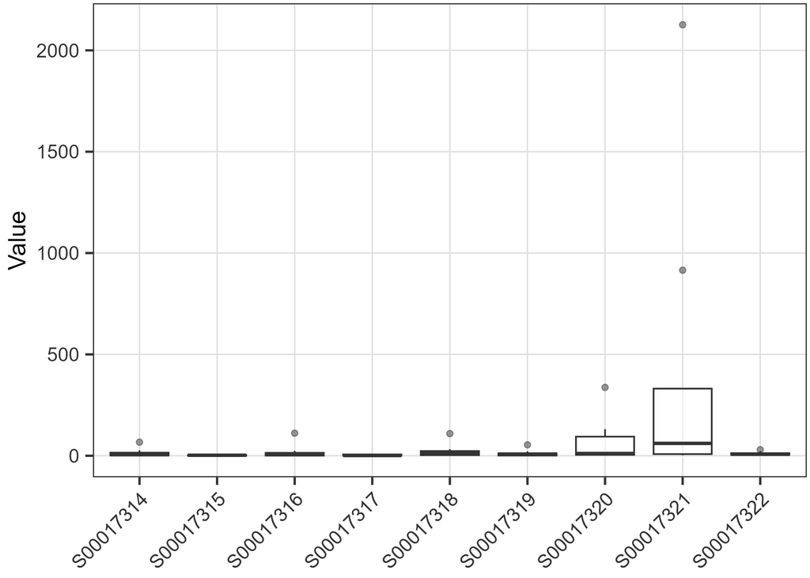

```r
## BOXPLOTS ##

p1 <- PomaBoxplots(poma_obj, x = "samples", feature_name = NULL)
p2 <- PomaBoxplots(normalized, x = "samples", feature_name = NULL)

ggsave("PomaBoxplots.png", plot = p1)
knitr::include_graphics("PomaBoxplots.png")
```

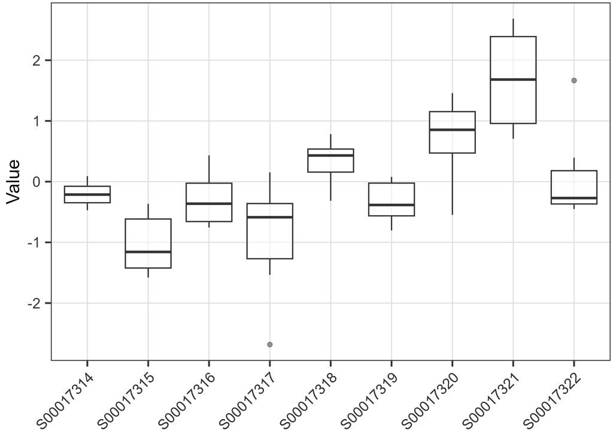

```r
ggsave("PomaBoxplotsNORM.png", plot = p2)
knitr::include_graphics("PomaBoxplotsNORM.png")
```

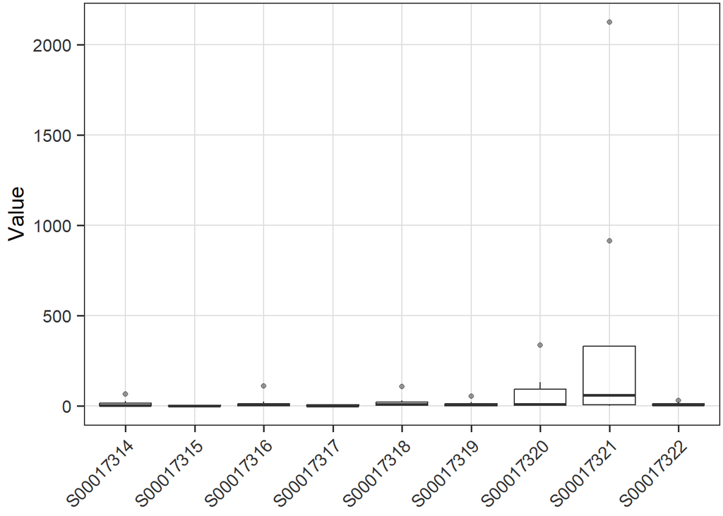

```r
# Mostrar los gráficos
print(p1)
```

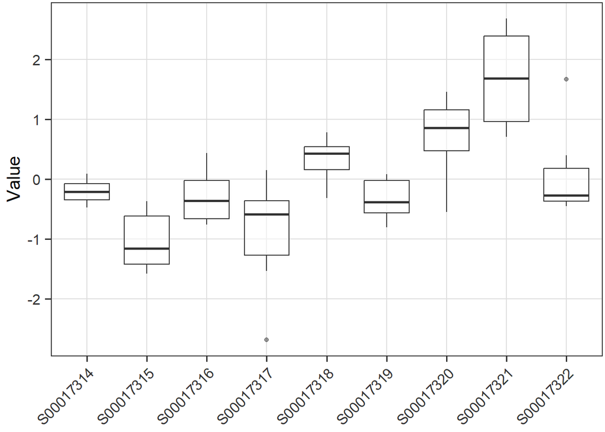

```r
print(p2)
```

```r
## DENSITY ##

#Arreglem els noms dels metabòlits que apareixen malament

feature_names <- json_data$MS_METABOLITE_DATA$Data$Metabolite
print(head(feature_names))
```

```
## [1] "11-deoxycortisol"       "11-DOC"                 "17-Hydroxyprogesterone"
## [4] "Androstenedione"        "Corticosterone"         "Cortisol"
```

```r
feature_names<-feature_names[-5]
length(feature_names)
```

```
## [1] 8
```

```r
length(assays(poma_obj))
```

```
## [1] 1
```

```r
# Asegurarte de que la longitud de 'feature_names' coincida con el número de filas de tu matriz de expresión
if (length(feature_names) == nrow(assays(poma_obj)[[1]])) {
  # Asignar los nuevos nombres a las características en el objeto SummarizedExperiment
  rownames(assays(poma_obj)[[1]]) <- feature_names
} else {
  stop("La longitud de los nombres de las características no coincide con el número de filas en la matriz de expresión.")
}

# Verifica los nuevos nombres de las características
print(rownames(assays(poma_obj)[[1]]))
```

```
## [1] "11-deoxycortisol"       "11-DOC"                 "17-Hydroxyprogesterone"
## [4] "Androstenedione"        "Cortisol"               "Cortisone"
## [7] "Progesterone"           "Testosterone"
```

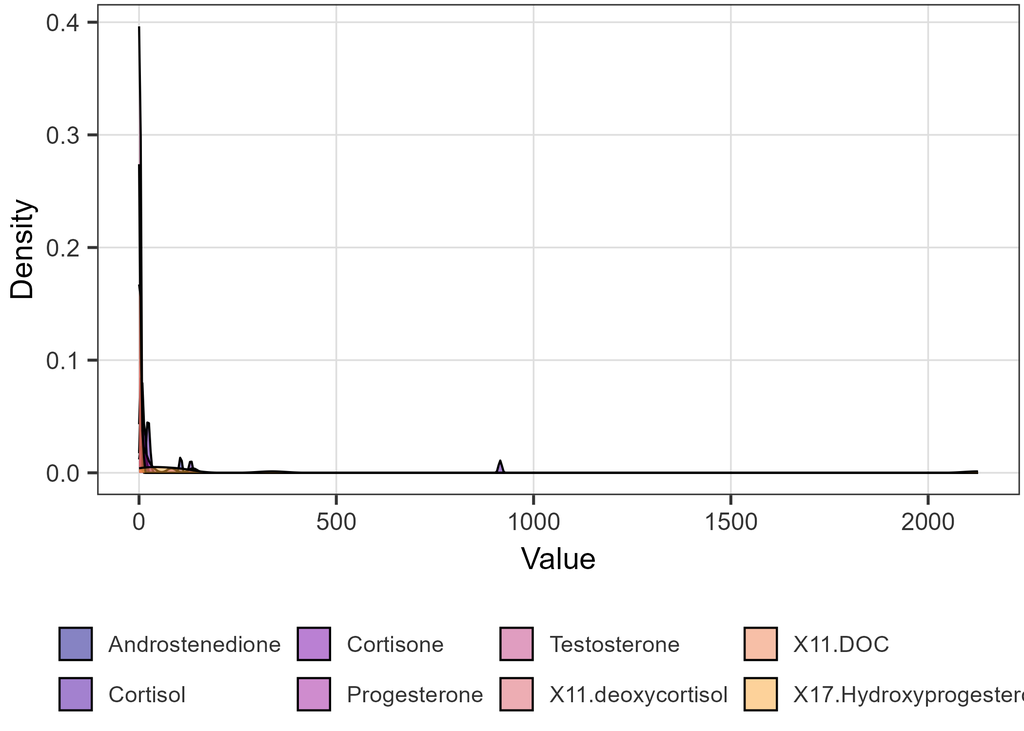

```r
p4<-PomaDensity(poma_obj, x = "features")
p5<-PomaDensity(normalized, x = "features")

ggsave("PomaDensity.png", plot = p4)
knitr::include_graphics("PomaDensity.png")
```

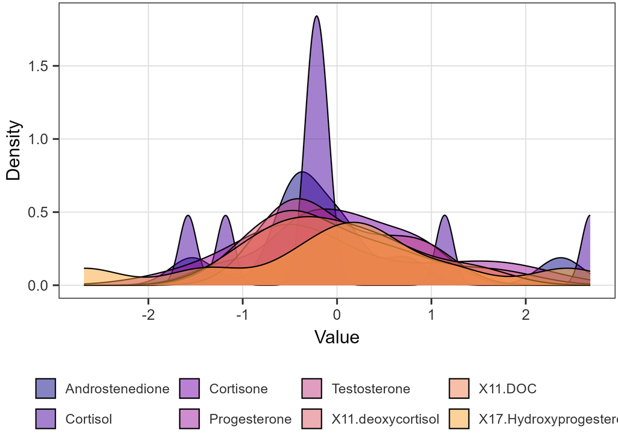

```r
ggsave("PomaDensityNORM.png", plot = p5)
knitr::include_graphics("PomaDensityNORM.png")
```

5. ANÀLISI DESCRIPTIU I ESTADÍSTIC 5.1 EXPLORACIÓ DE LES DADES

```r
assay_data <- assay(poma_obj)
assay(poma_obj, withDimnames = FALSE) <- assay_data
colnames(assay(poma_obj))
```

```
## [1] "S00017314" "S00017315" "S00017316" "S00017317" "S00017318" "S00017319"
## [7] "S00017320" "S00017321" "S00017322"
```

```r
assay_t<-t(log(assay_data))

### Correlació entre els metabòlits? ###

#Matriu de correlació

corr_matrix <- cor(assay_t)
corr_melted <- melt(corr_matrix)
corr_matrix
```

```
##                        11-deoxycortisol    11-DOC 17-Hydroxyprogesterone
## 11-deoxycortisol              1.0000000 0.6726553              0.3008073
## 11-DOC                        0.6726553 1.0000000              0.5644222
## 17-Hydroxyprogesterone        0.3008073 0.5644222              1.0000000
## Androstenedione               0.3516832 0.6272811              0.9053242
## Cortisol                      0.3737378 0.8468264              0.8282977
## Cortisone                     0.1615889 0.5064372              0.3583611
## Progesterone                  0.4253019 0.9180290              0.7121094
## Testosterone                  0.5895324 0.8659984              0.6024954
##                        Androstenedione  Cortisol Cortisone Progesterone
## 11-deoxycortisol             0.3516832 0.3737378 0.1615889    0.4253019
## 11-DOC                       0.6272811 0.8468264 0.5064372    0.9180290
## 17-Hydroxyprogesterone       0.9053242 0.8282977 0.3583611    0.7121094
## Androstenedione              1.0000000 0.8617441 0.3050357    0.7478992
## Cortisol                     0.8617441 1.0000000 0.5185368    0.9075314
## Cortisone                    0.3050357 0.5185368 1.0000000    0.5545130
## Progesterone                 0.7478992 0.9075314 0.5545130    1.0000000
## Testosterone                 0.6081589 0.7569257 0.4409134    0.8864611
##                        Testosterone
## 11-deoxycortisol          0.5895324
## 11-DOC                    0.8659984
## 17-Hydroxyprogesterone    0.6024954
## Androstenedione           0.6081589
## Cortisol                  0.7569257
## Cortisone                 0.4409134
## Progesterone              0.8864611
## Testosterone              1.0000000
```

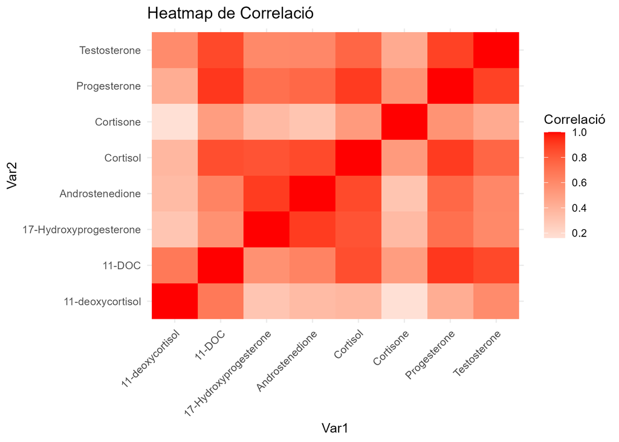

```r
# Heatmap metabolits

p6<-ggplot(corr_melted, aes(Var1, Var2, fill = value)) +
  geom_tile() +
  scale_fill_gradient2(low = "blue", mid = "white", high = "red", midpoint = 0) +
  theme_minimal() +
  labs(title = "Heatmap de Correlació", fill = "Correlació") +
  theme(axis.text.x = element_text(angle = 45, hjust = 1))

ggsave("HeatmapMetabol.png", plot = p6)
knitr::include_graphics("HeatmapMetabol.png")
```

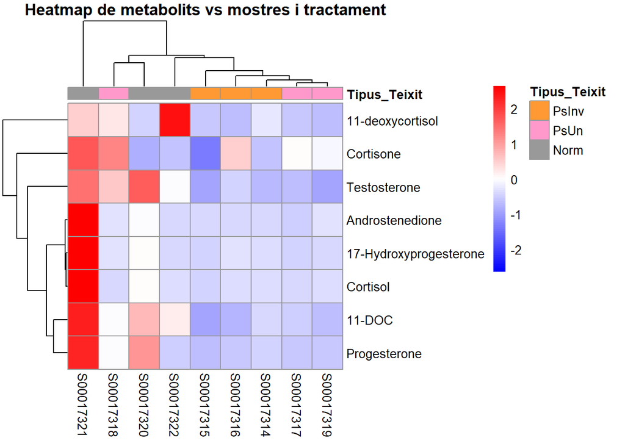

```r
### Perfils metabolòmics pareguts entre dades? ###

## Heatmap metabolits i mostres by tractament ##

# Anotem les mostres per tractament
tractaments <- data.frame(Tipus_Teixit = c("PsInv", "PsInv", "PsInv",
                                               "PsUn", "PsUn", "PsUn",
                                               "Norm", "Norm", "Norm"))
rownames(tractaments) <- colnames(assay_data)  # Nombres de las Mostras deben coincidir

# Definir colors per tractament
library(RColorBrewer)
colors_tractament <- list(Tipus_Teixit = c("PsInv" = "#FF9933","PsUn"="#FF99CC" , "Norm" = "#999"))

# Generar el heatmap con anotaciones y colores de grupos
p7<-pheatmap(as.matrix(assay_data),
         annotation_col = tractaments,  # Anotación para columnas (Mostras)
         annotation_colors = colors_tractament,  # Colores por grupo
         scale = "row",  # Normaliza los valores por fila (metabolitos)
         color = colorRampPalette(c("blue", "white", "red"))(100),  # Esquema de colores del heatmap
         clustering_distance_rows = "euclidean",
         clustering_distance_cols = "euclidean",
         clustering_method = "complete",
         main = "Heatmap de metabolits vs mostres i tractament")
```

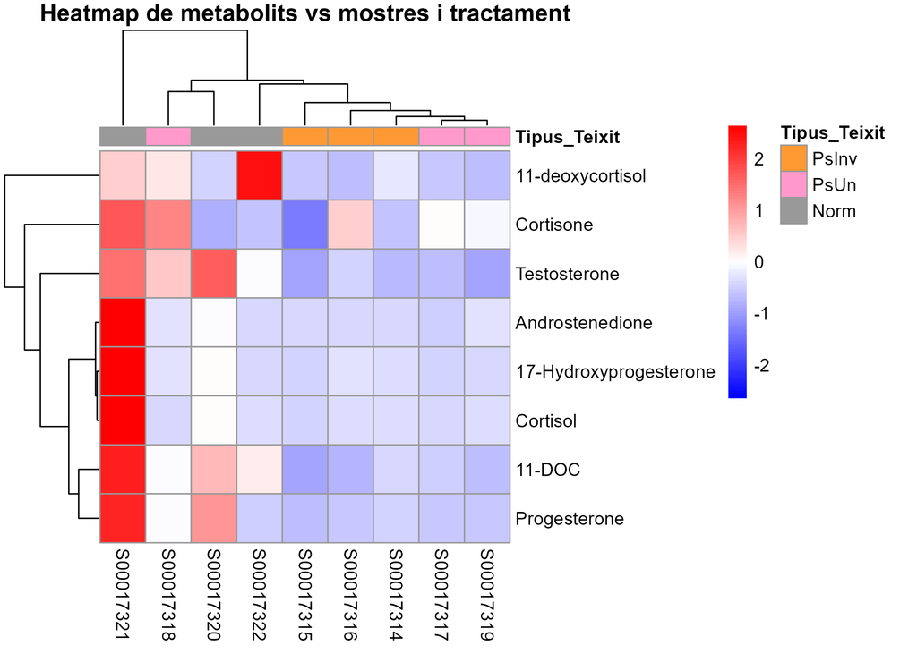

```r
ggsave("HeatmapFull.png", plot = p7)
knitr::include_graphics("HeatmapFull.png")
```

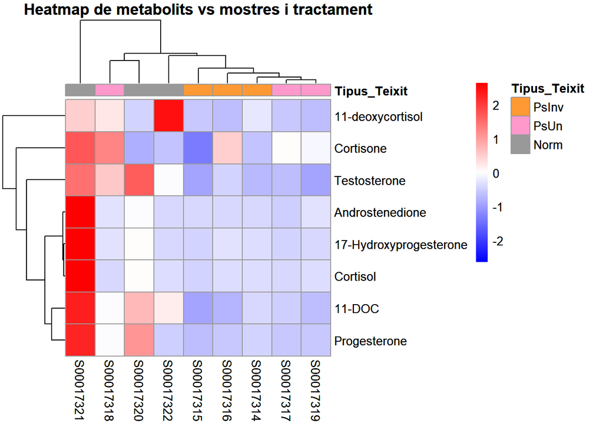

```r
p7
```

```r
## Perfils de les mostres per tractament ##
tractaments <- data.frame(
  Mostra = rownames(assay_t),
  Tractament = rep(c("PsInv", "PsUn", "Norm"), each = 3)
)
assay_t <- as.data.frame(assay_t)  # Convertimos assay_t a dataframe si no lo es
assay_t$Tractament <- tractaments$Tractament  # Añadir la columna 'Tractament'
assay_t$Mostra <- tractaments$Mostra
head(assay_t)
```

```
##           11-deoxycortisol      11-DOC 17-Hydroxyprogesterone Androstenedione
## S00017314        0.3576744  0.71783979               4.204394       1.3912819
## S00017315       -0.4942963 -0.73396918               1.921325       1.5303947
## S00017316       -1.1711830 -0.03045921               4.712678       1.3402504
## S00017317       -0.5621189  0.56531381              -1.714798      -0.5108256
## S00017318        0.9858168  1.11514159               4.694096       2.0425182
## S00017319       -1.3470736  0.25464222               3.987316       2.0806908
##           Cortisol Cortisone Progesterone Testosterone Tractament    Mostra
## S00017314 3.280911  1.824549    2.4292177   -0.7765288      PsInv S00017314
## S00017315 1.193922  1.029619    0.7129498   -1.2039728      PsInv S00017315
## S00017316 3.182212  2.397895    1.9671124   -0.3424903      PsInv S00017316
## S00017317 1.808289  2.186051    1.9643112   -0.6161861       PsUn S00017317
## S00017318 3.000720  2.660260    3.4685445    0.4637340       PsUn S00017318
## S00017319 3.077312  2.128232    2.1234584   -1.2378744       PsUn S00017319
```

```r
assay_t_long <- assay_t %>%
  pivot_longer(cols = -c(Tractament,Mostra),  # Mantener 'Tractament' como columna fija
               names_to = "Metabolit",
               values_to = "Concentracio")  # Los metabolitos se convierten en filas
```

PCA

```r
#Definim els factors
assay_t$Tractament<-as.factor(assay_t$Tractament)
assay_t$Mostra<-as.factor(assay_t$Mostra)
str(assay_t)
```

```
## 'data.frame':    9 obs. of  10 variables:
##  $ 11-deoxycortisol      : num  0.358 -0.494 -1.171 -0.562 0.986 ...
##  $ 11-DOC                : num  0.7178 -0.734 -0.0305 0.5653 1.1151 ...
##  $ 17-Hydroxyprogesterone: num  4.2 1.92 4.71 -1.71 4.69 ...
##  $ Androstenedione       : num  1.391 1.53 1.34 -0.511 2.043 ...
##  $ Cortisol              : num  3.28 1.19 3.18 1.81 3 ...
##  $ Cortisone             : num  1.82 1.03 2.4 2.19 2.66 ...
##  $ Progesterone          : num  2.429 0.713 1.967 1.964 3.469 ...
##  $ Testosterone          : num  -0.777 -1.204 -0.342 -0.616 0.464 ...
##  $ Tractament            : Factor w/ 3 levels "Norm","PsInv",..: 2 2 2 3 3 3 1 1 1
##  $ Mostra                : Factor w/ 9 levels "S00017314","S00017315",..: 1 2 3 4 5 6 7 8 9
```

```r
summary(assay_t)
```

```
##  11-deoxycortisol       11-DOC        17-Hydroxyprogesterone Androstenedione
##  Min.   :-1.34707   Min.   :-0.7340   Min.   :-1.715         Min.   :-0.5108
##  1st Qu.:-0.56212   1st Qu.: 0.2546   1st Qu.: 3.396         1st Qu.: 1.3913
##  Median :-0.07257   Median : 0.7178   Median : 4.204         Median : 1.5810
##  Mean   : 0.11557   Mean   : 0.7954   Mean   : 3.854         Mean   : 1.8834
##  3rd Qu.: 0.98582   3rd Qu.: 1.3191   3rd Qu.: 4.713         3rd Qu.: 2.0807
##  Max.   : 2.14089   Max.   : 2.2905   Max.   : 7.662         Max.   : 4.6565
##
##     Cortisol       Cortisone      Progesterone     Testosterone     Tractament
##  Min.   :1.194   Min.   :1.030   Min.   :0.7129   Min.   :-1.2379   Norm :3
##  1st Qu.:3.001   1st Qu.:1.792   1st Qu.:1.9671   1st Qu.:-0.7765   PsInv:3
##  Median :3.135   Median :2.128   Median :2.2289   Median :-0.3425   PsUn :3
##  Mean   :3.375   Mean   :2.051   Mean   :2.6909   Mean   :-0.1985
##  3rd Qu.:3.281   3rd Qu.:2.398   3rd Qu.:3.4685   3rd Qu.: 0.4637
##  Max.   :6.819   Max.   :2.809   Max.   :4.9154   Max.   : 0.9517
##
##        Mostra
##  S00017314:1
##  S00017315:1
##  S00017316:1
##  S00017317:1
##  S00017318:1
##  S00017319:1
##  (Other)  :3
```

```r
#Separem les variables numèriques
assay_t_numeric <- assay_t[, sapply(assay_t, is.numeric)]

# Matriu de correlació #
cor_matrix <- cor(assay_t_numeric, use = "pairwise.complete.obs", method = "pearson")
print(cor_matrix)
```

```
##                        11-deoxycortisol    11-DOC 17-Hydroxyprogesterone
## 11-deoxycortisol              1.0000000 0.6726553              0.3008073
## 11-DOC                        0.6726553 1.0000000              0.5644222
## 17-Hydroxyprogesterone        0.3008073 0.5644222              1.0000000
## Androstenedione               0.3516832 0.6272811              0.9053242
## Cortisol                      0.3737378 0.8468264              0.8282977
## Cortisone                     0.1615889 0.5064372              0.3583611
## Progesterone                  0.4253019 0.9180290              0.7121094
## Testosterone                  0.5895324 0.8659984              0.6024954
##                        Androstenedione  Cortisol Cortisone Progesterone
## 11-deoxycortisol             0.3516832 0.3737378 0.1615889    0.4253019
## 11-DOC                       0.6272811 0.8468264 0.5064372    0.9180290
## 17-Hydroxyprogesterone       0.9053242 0.8282977 0.3583611    0.7121094
## Androstenedione              1.0000000 0.8617441 0.3050357    0.7478992
## Cortisol                     0.8617441 1.0000000 0.5185368    0.9075314
## Cortisone                    0.3050357 0.5185368 1.0000000    0.5545130
## Progesterone                 0.7478992 0.9075314 0.5545130    1.0000000
## Testosterone                 0.6081589 0.7569257 0.4409134    0.8864611
##                        Testosterone
## 11-deoxycortisol          0.5895324
## 11-DOC                    0.8659984
## 17-Hydroxyprogesterone    0.6024954
## Androstenedione           0.6081589
## Cortisol                  0.7569257
## Cortisone                 0.4409134
## Progesterone              0.8864611
## Testosterone              1.0000000
```

```r
cor_table <- as.data.frame(round(cor_matrix, 2))  # Redondear a 2 decimales

# La guardem en Taula #
kable(cor_table, caption = "Matriz de Correlación de las Variables Numéricas") %>%
  kable_styling(bootstrap_options = c("striped", "hover", "condensed", "responsive"))
```

Matriz de Correlación de las Variables Numéricas

|  | 11-deoxycortisol | 11-DOC | 17-Hydroxyprogesterone | Androstenedione | Cortisol | Cortisone | Progesterone | Testosterone |
| --- | --- | --- | --- | --- | --- | --- | --- | --- |
| 11-deoxycortisol | 1.00 | 0.67 | 0.30 | 0.35 | 0.37 | 0.16 | 0.43 | 0.59 |
| 11-DOC | 0.67 | 1.00 | 0.56 | 0.63 | 0.85 | 0.51 | 0.92 | 0.87 |
| 17-Hydroxyprogesterone | 0.30 | 0.56 | 1.00 | 0.91 | 0.83 | 0.36 | 0.71 | 0.60 |
| Androstenedione | 0.35 | 0.63 | 0.91 | 1.00 | 0.86 | 0.31 | 0.75 | 0.61 |
| Cortisol | 0.37 | 0.85 | 0.83 | 0.86 | 1.00 | 0.52 | 0.91 | 0.76 |
| Cortisone | 0.16 | 0.51 | 0.36 | 0.31 | 0.52 | 1.00 | 0.55 | 0.44 |
| Progesterone | 0.43 | 0.92 | 0.71 | 0.75 | 0.91 | 0.55 | 1.00 | 0.89 |
| Testosterone | 0.59 | 0.87 | 0.60 | 0.61 | 0.76 | 0.44 | 0.89 | 1.00 |

```r
# Matriu de covariàncies #

assay_t_numeric <- assay_t[, sapply(assay_t, is.numeric)]
cov_matrix <- cov(assay_t_numeric, use = "pairwise.complete.obs")
print(cov_matrix)
```

```
##                        11-deoxycortisol    11-DOC 17-Hydroxyprogesterone
## 11-deoxycortisol              1.3452453 0.7156819              0.9140475
## 11-DOC                        0.7156819 0.8414988              1.3564711
## 17-Hydroxyprogesterone        0.9140475 1.3564711              6.8637182
## Androstenedione               0.5613654 0.7919217              3.2642028
## Cortisol                      0.7131581 1.2780245              3.5701320
## Cortisone                     0.1033034 0.2560677              0.5174913
## Progesterone                  0.6542022 1.1168557              2.4742316
## Testosterone                  0.5736461 0.6664683              1.3242473
##                        Androstenedione  Cortisol Cortisone Progesterone
## 11-deoxycortisol             0.5613654 0.7131581 0.1033034    0.6542022
## 11-DOC                       0.7919217 1.2780245 0.2560677    1.1168557
## 17-Hydroxyprogesterone       3.2642028 3.5701320 0.5174913    2.4742316
## Androstenedione              1.8940288 1.9511456 0.2313910    1.3650555
## Cortisol                     1.9511456 2.7066753 0.4702190    1.9801299
## Cortisone                    0.2313910 0.4702190 0.3038120    0.4053481
## Progesterone                 1.3650555 1.9801299 0.4053481    1.7588461
## Testosterone                 0.7021761 1.0447370 0.2038879    0.9863005
##                        Testosterone
## 11-deoxycortisol          0.5736461
## 11-DOC                    0.6664683
## 17-Hydroxyprogesterone    1.3242473
## Androstenedione           0.7021761
## Cortisol                  1.0447370
## Cortisone                 0.2038879
## Progesterone              0.9863005
## Testosterone              0.7038357
```

```r
# Fem la PCA de manera més ràpida amb 'prcomp'

pca_result <- prcomp(assay_t_numeric, scale. = TRUE)
summary(pca_result)
```

```
## Importance of components:
##                           PC1    PC2    PC3     PC4    PC5     PC6     PC7
## Standard deviation     2.3368 1.0021 0.9156 0.62337 0.4252 0.27654 0.21047
## Proportion of Variance 0.6826 0.1255 0.1048 0.04857 0.0226 0.00956 0.00554
## Cumulative Proportion  0.6826 0.8081 0.9129 0.96149 0.9841 0.99365 0.99919
##                            PC8
## Standard deviation     0.08067
## Proportion of Variance 0.00081
## Cumulative Proportion  1.00000
```

```r
PCAS1 <- pca_result$x[, 1]  # Primera PC
PCAS2 <- pca_result$x[, 2]  # Segona PC
PCAS1
```

```
##  S00017314  S00017315  S00017316  S00017317  S00017318  S00017319  S00017320
##  0.5284606  3.1833307  0.8347477  2.3519908 -1.1874271  1.1525679 -2.0778639
##  S00017321  S00017322
## -4.4589130 -0.3268937
```

```r
PCAS2
```

```
##   S00017314   S00017315   S00017316   S00017317   S00017318   S00017319
## -0.06145546  0.35531422  1.09313595 -1.11064487 -0.61959400  1.40986276
##   S00017320   S00017321   S00017322
##  0.20996239  0.42124451 -1.69782549
```

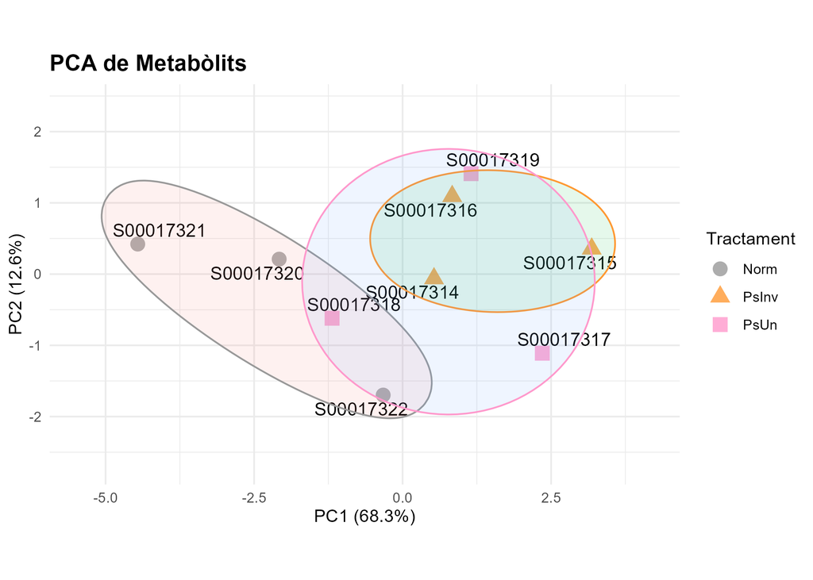

```r
# Plot de la PCA
pca_df <- data.frame(
  PC1 = pca_result$x[, 1],
  PC2 = pca_result$x[, 2],
  Muestra = rownames(assay_t_numeric),
  Tractament = assay_t$Tractament  # Assegura't que aquest factor estigui correctament assignat
)

# Colors personalitzats per cada tractament
colors_trat <- c("PsInv" = "#FF9933","PsUn"="#FF99CC" , "Norm" = "#999")

#  Gràfic de PCA vs metabòlits #

p8<-ggplot(pca_df, aes(x = PC1, y = PC2, color = Tractament, shape = Tractament)) +
  geom_point(size = 4, alpha = 0.8) +  # Punts
  geom_text_repel(aes(label = Muestra), size = 4, color = "black", max.overlaps = Inf) +  # Etiquetes
  geom_mark_ellipse(aes(fill = Tractament), alpha = 0.1, show.legend = FALSE) +  # El·lipses
  scale_color_manual(values = colors_trat) +  # Assignació de colors personalitzats
  scale_shape_manual(values = c(16, 17, 15)) +  # Formes diferents per tractaments
  theme_minimal() +
  labs(title = "PCA de Metabòlits",
       x = paste0("PC1 (", round(summary(pca_result)$importance[2, 1] * 100, 1), "%)"),
       y = paste0("PC2 (", round(summary(pca_result)$importance[2, 2] * 100, 1), "%)")) +
  expand_limits(x = c(min(pca_df$PC1) - 1, max(pca_df$PC1) + 1),
                y = c(min(pca_df$PC2) - 1, max(pca_df$PC2) + 1)) +  # Ampliar marges
  coord_fixed(ratio = 1.2) +  # Ajusta la relació entre eixos
  theme(legend.position = "right",
        plot.title = element_text(size = 14, face = "bold"))

ggsave("PCA.png", plot = p8)
knitr::include_graphics("PCA.png")
```